# Explorary Data Analysis - Milestone Report - Week 2

S Ridgway

2023-02-10

## *Data Science Specialization Capstone Project*

The goal of this project is to demonstrate that i have loaded in the required dataset and become familiar with it using exploratory analysis techniques. This report will be a brief outline of this analysis and how i intend to move forward to my predictive model.

The first step in building a predictive model for text is understanding the distribution and relationship between the words, tokens, and phrases in the text. The goal of this task is to understand the basic relationships you observe in the data and prepare to build your first linguistic models.

This report is intended for a non-data scientist manager and thus i have hidden the R Code Chunks but the full RMD file can be found here.(https://github.com/Ridgway1000/Capstone-Project)

## The Data Load

For the initial data-load i decided to only load in the English (US) version of each file. This consists of three large text files for Blogs, News and Twitter. First of all i built an overview of the files, displayed in the table below to show the size of each data-set that i was working with. We can see these are incredibly large and very memory intensive.

| file | Totals totalLines | Totals totalWords | Totals totalChars | Words averageWords | Words minWords | Words maxWords | Characters averageChars | Characters minChars | Characters maxChars |
| --- | --- | --- | --- | --- | --- | --- | --- | --- | --- |
| blogs | 899288 | 37546250 | 206824382 | 41.75109 | 0 | 6726 | 229.98666 | 1 | 40833 |
| news | 77259 | 2674536 | 15639408 | 34.61779 | 1 | 1123 | 202.42830 | 2 | 5760 |
| twitter | 2360148 | 30093413 | 162096241 | 12.75065 | 1 | 47 | 68.68043 | 2 | 140 |

## Tokenizing the subsetted data and demonstrate frequency of words (N- Grams)

The next step i took was to tokenize the cleaned up data which splits each word into its own row. As part of this process i also removed any ‘stopwords’, which are extremely common words not valuable for an analysis for example a, of, the, etc.

Using the tokenized data, i plotted the most common singular words into the table below:

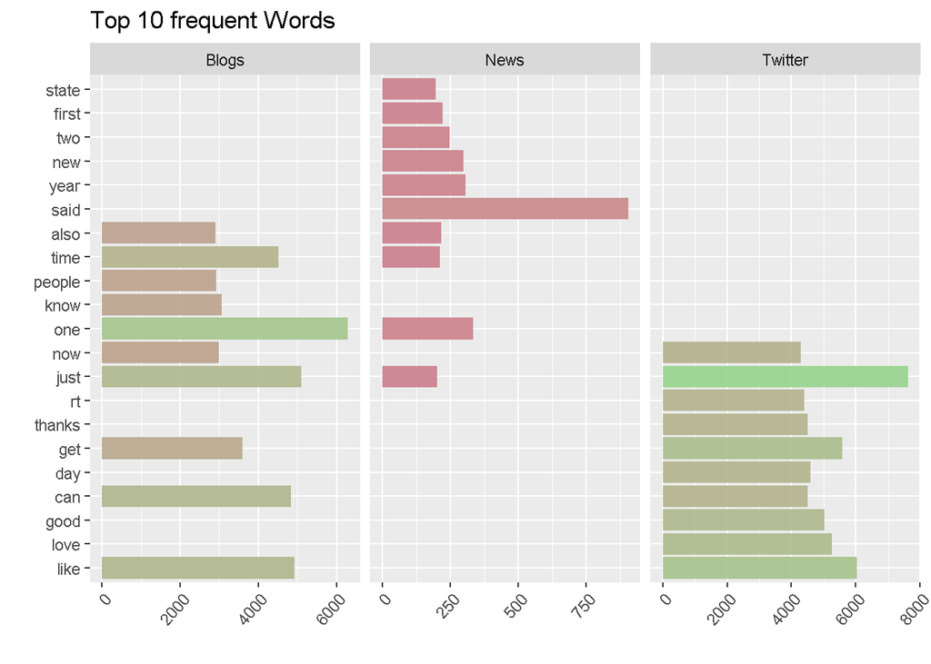

## Bi-Grams and Trigrams

I decided after this initial exploration of most common singular words to also map this out visually for both Bi-Grams (2 word) and Tri-Grams (3 word) frequencies.

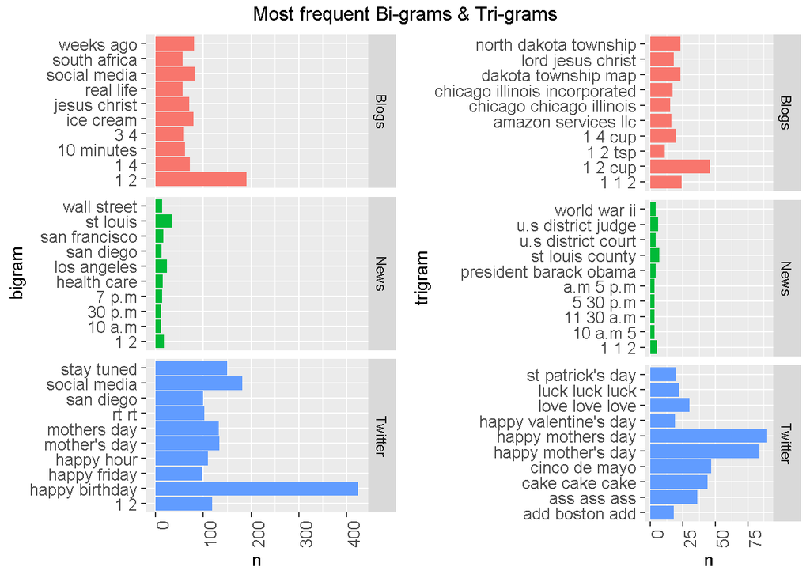

## Word Cloud on Overall file.

Finally, i decided to bind my 3 tokenized files together into 1 file to visualize into word clouds below. The word clouds are restricted by a minimum frequency of 75 (N), 40 (Bi) and 3(Tri) for a more appropriate visual.

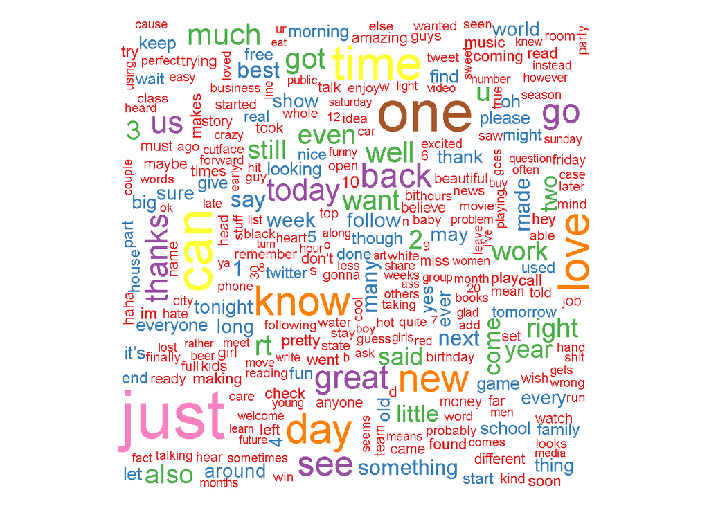

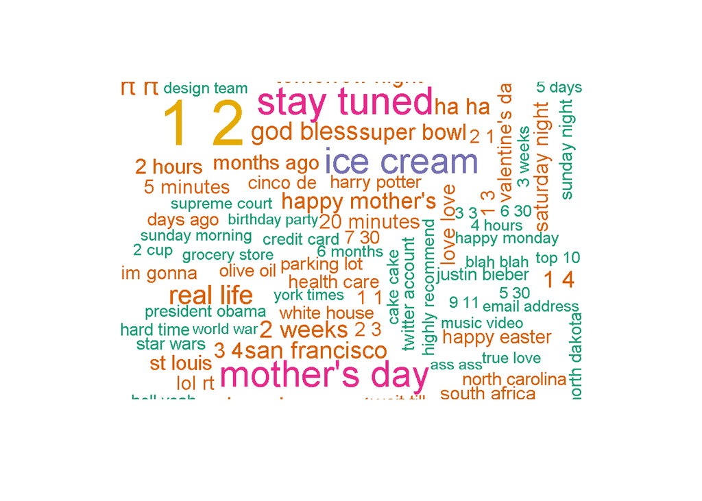

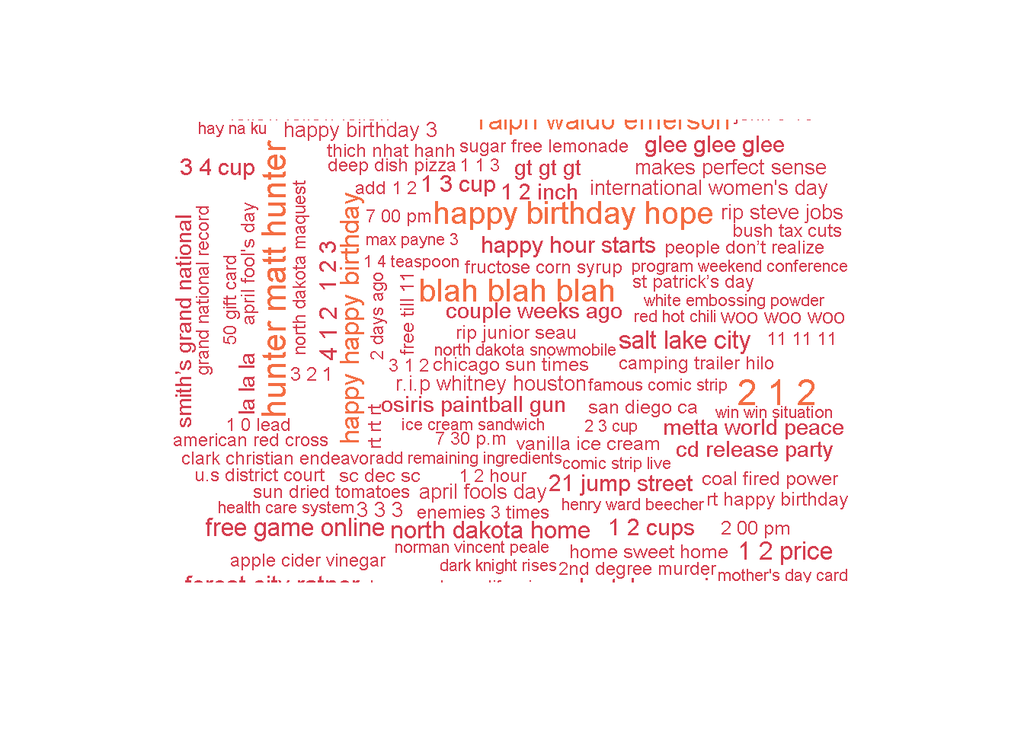

## Summary

As i have established, the data sets are large and processing them requires time and computing resources.By analysing the frequencies it may be possible to ignore ‘rare’ words within our Corpus leading to a less comprehensive but more efficient predictive model. It is important to find the balance in my final outcome.

In the final model, the data will need to be cleaned some more (remove numbers, check punctuation etc) and contained within one Corpus. I will then use the tokenized ngrams approach to build an algorithm (like the Hidden Markov model) to predict the next word given the preceding one.